## Librerias

```python
import numpy as np
import numpy.linalg as LA
import pandas as pd
import matplotlib.pyplot as plt
from sklearn.preprocessing import StandardScaler
SS    = StandardScaler()
D     = 57
FOLDS = 5
np.seterr(divide = 'ignore')
```

```
{'divide': 'warn', 'over': 'warn', 'under': 'ignore', 'invalid': 'warn'}
```

# Conjuto de datos

```python
# Nombre de columnas
headers = "Word_freq_make, Word_freq_address, Word_freq_all, Word_freq_3d, Word_freq_our, Word_freq_over, Word_freq_remove, Word_freq_internet, Word_freq_order, Word_freq_mail, Word_freq_receive, Word_freq_will, Word_freq_people, Word_freq_report, Word_freq_addresses, Word_freq_free, Word_freq_business, Word_freq_email, Word_freq_you, Word_freq_credit, Word_freq_your, Word_freq_font, Word_freq_000, Word_freq_money, Word_freq_hp, Word_freq_hpl, Word_freq_george, Word_freq_650, Word_freq_lab, Word_freq_labs, Word_freq_telnet, Word_freq_857, Word_freq_data, Word_freq_415, Word_freq_85, Word_freq_technology, Word_freq_1999, Word_freq_parts, Word_freq_pm, Word_freq_direct, Word_freq_cs, Word_freq_meeting, Word_freq_original, Word_freq_project, Word_freq_re, Word_freq_edu, Word_freq_table, Word_freq_conference, Char_freq1, Char_freq2, Char_freq3, Char_freq4, Char_freq5, Char_freq6, Capital_run_length_average, Capital_run_length_longest, Capital_run_length_total"
# Concatenacion de columnas con la columna de clase(Spam)
headers = np.concatenate([np.array(headers.split(",")),["Spam"]],axis=0)
```

```python
getTrainingDataset = lambda i: pd.read_csv("./data/spambase-5-{}tra.dat".format(i),sep=",",header=None)
getTestingDataset  = lambda i: pd.read_csv("./data/spambase-5-{}tst.dat".format(i),sep=",",header=None)
def setColumnsToDataframe(df):
    df.columns=headers
    return df
def getDataAndTarget(df):
    X = df.values
    y = X[:,-1]
    return X[:,:-1],y
dfs_train          = [getTrainingDataset(i) for i in range(1,6) ]
dfs_train          = list(map(setColumnsToDataframe,dfs_train))
Xys_train          = list(map (getDataAndTarget,dfs_train) )
#
dfs_test           = [getTestingDataset(i) for i in range(1,6) ]
dfs_test           = list(map(setColumnsToDataframe,dfs_test))
Xys_test           = list(map (getDataAndTarget,dfs_test) )
```

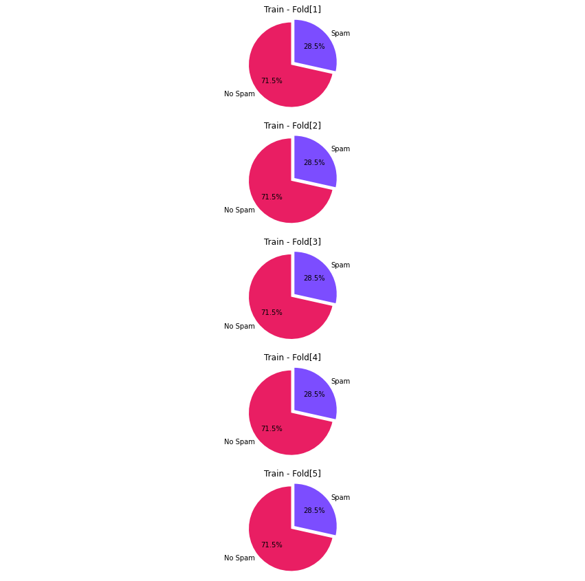

```python
# INDEX           = 3
_, ax       = plt.subplots(5,figsize=(15,15))
labels          = 'No Spam', 'Spam'
explode         = (0.1, 0 )
# print(ax[0])
for INDEX in range(FOLDS):
    X_train,y_train = Xys_train[INDEX]
    n               = y_train.shape[0]
    ones            = ((y_train.sum())/n)*100
    zero            = ((n - ones)/n)*100
    sizes           = [zero,ones]
    ax[INDEX].pie(sizes,
            explode=explode, labels=labels,
            autopct='%1.1f%%',
            shadow=False, startangle=90,colors=["#E91E63","#7C4DFF"])
    ax[INDEX].set_title("Train - Fold[{}]".format(INDEX+1))
    ax[INDEX].axis('equal')  # Equal aspect ratio ensures that pie is drawn as a circle.
```

# Clasificador bayesiano

```python
def getParameters(i):
    X , y   = Xys_train[i]
    _SS,(w0,w1) = getWiByClass(X,y)
    w0_mean = w0.mean(axis=0)
    w1_mean = w1.mean(axis=0)
    w0_cov  = np.cov(w0.T,bias=False)
    w1_cov  = np.cov(w1.T,bias=False)
    D       = X.shape[1]
    MEANS   = [w0_mean,w1_mean]
    COVS    = [w0_cov,w1_cov]
    Ns      = np.array([w0.shape[0],w1.shape[0]])
    return _SS,MEANS,COVS,Ns
# _SS,MEANS,COVS,Ns = getParameters(0)
```

```python
def px(x,mean,cov):
    xMean       =(x-mean)
    covInv      = LA.inv(cov)
    covDet      = LA.det(cov)
    exp         = (-0.5*xMean.T@covInv)@(xMean)
    denominator = np.power(2*np.pi,D/2)*np.sqrt(covDet)
    return (1/denominator)*exp
def classify(i,X,clf):
    _SS,MEANS,COVS,Ns = getParameters(i)
    _X = _SS.transform(X)
    results = []
    for xi in _X:
        results.append(clf(xi,MEANS,COVS,Ns= Ns))
    return np.array(results)
```

```python
def bayesClassifier(x,MEANS,COVS,**kwargs):
    results = []
    for wi_mean,wi_cov in zip(MEANS,COVS):
        results.append(px(x,wi_mean,wi_cov))
    results = np.array(results)
    return np.argmax(results)
```

## Clasificador de minima distancia Euclidiana

```python
def med_px(xi,MEANS,COVS,**kwargs):
    results = []
    for wi_mean,wi_cov in zip(MEANS,COVS):
        xMean = xi-wi_mean
        px = np.sqrt(xMean.T@xMean)
        results.append(px)
    return np.argmin(np.array(results))
```

## Clasificador de minima distancia Mahalanobis

```python
def mmd_px(xi,MEANS,COVS,**kwargs):
    results = []
    Ns = kwargs.get("Ns") -1
    _sigma = 0
    for  i,ni in enumerate(Ns):
        _sigma+=ni*COVS[i]
    _sigma = (1/(Ns.sum()))*_sigma
    for wi_mean,wi_cov in zip(MEANS,COVS):
        xMean = xi-wi_mean
        nis =(Ns[0]-1)+(Ns[1]-1)
#         sigma = ((1 / nis)*nis)*wi_cov
        px    = np.sqrt(xMean.T@_sigma@xMean)
        results.append(px)
    return np.argmin(np.array(results))
```

## Funcion discriminante cuadratico

```python
def fdc_px(xi,MEANS,COVS,**kwargs):
    results= []
    xi = xi.reshape(-1,1)
    for wi_mean,wi_cov in zip(MEANS,COVS):
        sigmaIv = LA.inv(wi_cov)
        Wi      = -0.5* sigmaIv
        wi      =  sigmaIv@wi_mean
        w0i     = (-0.5*wi_mean@sigmaIv@wi_mean*-.5*np.log(LA.det(wi_cov))) + np.log(0.5)
        gx      = xi.T@Wi@xi + wi.T@xi + w0i
        results.append(gx)
    return np.argmax(np.array(results))
```

```python
def test_bayesian_clf(clf):
    accuracies =[]
    for INDEX in range(FOLDS):
        X_test,y_test = Xys_test[INDEX]
        y_pred        = classify(INDEX,X_test,clf)
        accuracy      = get_accuracy(y_test,y_pred)
        accuracies.append(accuracy)
    return np.array(accuracies)
# test_bayesian_clf(bayesClassifier)
```

```python
bayesian_results = test_bayesian_clf(bayesClassifier)
```

```python
med_results = test_bayesian_clf(med_px)
```

```python
mmd_results = test_bayesian_clf(mmd_px)
```

```python
fdc_results = test_bayesian_clf(fdc_px)
```

```python
bayes_tresults = [bayesian_results.mean(), med_results.mean(),mmd_results.mean(),fdc_results.mean()]
bayes_tresults
```

```
[0.6058300610304206,
 0.8960174102285091,
 0.8435934617022284,
 0.6080056299380233]
```

## Resultados

```
[0 1 2 3]
```

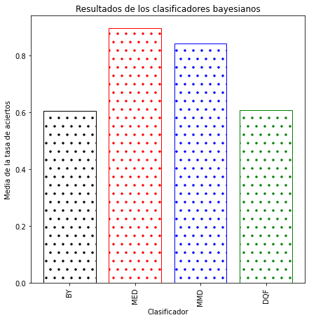

```python
def plot_mean(data,**kwargs):
    TITLE  = kwargs.get("title","Resultados de los clasificadores bayesianos")
    XLABEL = kwargs.get("x_label","Clasificador")
    YLABEL = kwargs.get("y_label","Media de la tasa de aciertos")
    XTICKS = kwargs.get("x_ticks",["BY","MED","MMD","DQF"])
    _,ax = plt.subplots(figsize=(7,7))
    ax.set_title(TITLE)
    ax.set_xlabel(XLABEL)
    ax.set_ylabel(YLABEL)
#     x_labels =
    heights = np.array(data)
#     print(heights)
    x   = np.array(range(heights.shape[0]))
    print(x)
    plt.xticks(x, XTICKS, rotation="vertical")
#     ax.bar(x,heights,color=["#F44336","#FF4081","#9C27B0","#FFEB3B","#CDDC39"])
    ax.bar(x,heights,color=["#fff"],hatch=".",edgecolor=["black","red","blue","green","gray"])
plot_mean(bayes_tresults)
plt.savefig("p0",dpi=300)
# plot_mean(perceptron_results)
```

### Vectores de medias y matriz de covarianza

#### Fold (0)

```python
_,MEANS_0,COVS_0,_ = getParameters(0)
```

Vector de medias de la clase $\omega_{0}$

```python
MEANS_0[0]
```

```
array([-0.09786684,  0.02347241, -0.14651997, -0.04543719, -0.19293941,
       -0.17813187, -0.26235708, -0.15892051, -0.19448058, -0.11417783,
       -0.19438013, -0.00377111, -0.11469138, -0.04000108, -0.15915472,
       -0.25311769, -0.21167766, -0.16597321, -0.22492542, -0.14470264,
       -0.30087737, -0.07223494, -0.27587023, -0.17490351,  0.20753471,
        0.19414441,  0.14739087,  0.12449734,  0.10569393,  0.14175856,
        0.1001538 ,  0.09221868,  0.10773522,  0.09083292,  0.11879022,
        0.11163934,  0.14296409,  0.02662825,  0.09820954,  0.0565916 ,
        0.0794169 ,  0.10894952,  0.10926151,  0.07754006,  0.11059032,
        0.11659291,  0.03731157,  0.0647309 ,  0.04738994,  0.07504799,
        0.04752756, -0.17798417, -0.26488646, -0.0523938 , -0.08787158,
       -0.16966765, -0.20309663])
```

Matriz de covarianza de cla clase $\omega_0$

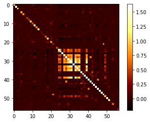

```python
def showCov(cov):
    plt.imshow(cov, interpolation='nearest', cmap=plt.cm.afmhot)
    plt.colorbar()
    plt.show()
showCov(COVS_0[0])
```

Vector de medias de la clase $\omega_{1}$

```python
MEANS_0[1]
```

```
array([ 0.15048125, -0.03609146,  0.22529088,  0.06986478,  0.29666598,
        0.27389773,  0.40340343,  0.2443581 ,  0.29903571,  0.17556122,
        0.29888125,  0.0057985 ,  0.17635086,  0.06150615,  0.24471823,
        0.38919683,  0.32547815,  0.25520242,  0.34584805,  0.22249653,
        0.4626327 ,  0.11106932,  0.42418141,  0.26893376, -0.3191079 ,
       -0.2985188 , -0.22662999, -0.19142863, -0.16251628, -0.21796969,
       -0.1539977 , -0.14179656, -0.16565498, -0.13966581, -0.18265329,
       -0.17165801, -0.21982332, -0.04094393, -0.15100818, -0.08701593,
       -0.1221124 , -0.1675221 , -0.16800182, -0.11922654, -0.17004502,
       -0.17927467, -0.05737073, -0.09953103, -0.07286735, -0.1153947 ,
       -0.07307895,  0.27367062,  0.40729263,  0.08056134,  0.13511241,
        0.26088304,  0.31228385])
```

Matriz de covarianza de cla clase $\omega_1$

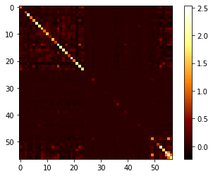

```python
showCov(COVS_0[1])
```

### Fold (1)

```python
_,MEANS_1,COVS_1,_ = getParameters(1)
```

Vector de medias de la clase $\omega_{0}$

```python
MEANS_1[0]
```

```
array([-0.10549811,  0.01944415, -0.16189121, -0.04691571, -0.19712673,
       -0.18855473, -0.28136189, -0.16494234, -0.18927349, -0.13122515,
       -0.19259249, -0.00169166, -0.11106761, -0.05331613, -0.15740977,
       -0.20596855, -0.21678754, -0.16531735, -0.22146269, -0.14938107,
       -0.3199658 , -0.0645282 , -0.26826392, -0.16800384,  0.20820379,
        0.18414413,  0.14732564,  0.13299692,  0.10764729,  0.13565034,
        0.10236758,  0.09417338,  0.0952538 ,  0.09428934,  0.11670606,
        0.10917609,  0.14369346,  0.01883474,  0.09709588,  0.05002334,
        0.0772024 ,  0.10857602,  0.10902983,  0.07261045,  0.11170356,
        0.11581603,  0.03795334,  0.06836823,  0.04664873,  0.0672085 ,
        0.04878329, -0.28543721, -0.28531586, -0.05601506, -0.09631639,
       -0.16667608, -0.20990531])
```

Matriz de covarianza de cla clase $\omega_0$

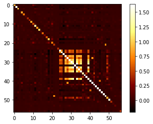

```python
showCov(COVS_1[0])
```

Vector de medias de la clase $\omega_{1}$

```python
MEANS_1[1]
```

```
array([ 0.16221518, -0.02989756,  0.24892589,  0.07213817,  0.30310446,
        0.28992405,  0.43262547,  0.25361734,  0.29102922,  0.20177339,
        0.29613255,  0.00260111,  0.1707789 ,  0.08197953,  0.24203518,
        0.31669974,  0.33333515,  0.25419396,  0.34052372,  0.22969015,
        0.4919833 ,  0.09921934,  0.41248586,  0.25832474, -0.32013668,
       -0.28314225, -0.22652969, -0.20449768, -0.16551978, -0.20857761,
       -0.15740163, -0.14480213, -0.14646339, -0.14498044, -0.17944866,
       -0.16787048, -0.22094482, -0.02896052, -0.1492958 , -0.0769165 ,
       -0.11870734, -0.16694781, -0.1676456 , -0.11164671, -0.17175675,
       -0.17808013, -0.05835752, -0.10512382, -0.07172765, -0.10334061,
       -0.07500977,  0.43889171,  0.43870513,  0.08612944,  0.14809726,
        0.25628317,  0.32275295])
```

Matriz de covarianza de cla clase $\omega_1$

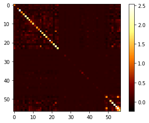

```python
showCov(COVS_1[1])
```

### Fold (2)

```python
_,MEANS_2,COVS_2,_ = getParameters(2)
```

Vector de medias de la clase $\omega_{0}$

```python
MEANS_2[0]
```

```
array([-0.10104698,  0.02564947, -0.16385503, -0.03852444, -0.19219634,
       -0.1779265 , -0.26843795, -0.17407   , -0.18145242, -0.10829339,
       -0.18861378, -0.01380569, -0.10307478, -0.04165082, -0.15505862,
       -0.20324042, -0.21276012, -0.17172709, -0.22733476, -0.14961065,
       -0.30224429, -0.07307322, -0.26995075, -0.16925203,  0.20829218,
        0.1880842 ,  0.14660156,  0.12511306,  0.10594606,  0.13819097,
        0.10002963,  0.09165637,  0.0917262 ,  0.08994699,  0.13688918,
        0.11375004,  0.15425452,  0.02603883,  0.09822494,  0.0540861 ,
        0.07832666,  0.11012866,  0.11180078,  0.07563801,  0.11172446,
        0.12068499,  0.03533142,  0.08009684,  0.04890623,  0.06215039,
        0.0518839 , -0.18561841, -0.25189272, -0.05310823, -0.08852428,
       -0.16471014, -0.19469641])
```

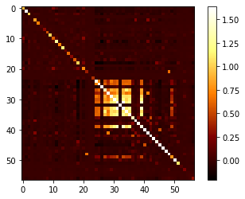

```python
showCov(COVS_2[0])
```

Vector de medias de la clase $\omega_{1}$

```python
MEANS_2[1]
```

```
array([ 0.1552639 , -0.03941174,  0.25177172,  0.0591948 ,  0.29531962,
        0.27339326,  0.41246879,  0.26746756,  0.27881103,  0.1663984 ,
        0.28981483,  0.02121316,  0.15837973,  0.06399864,  0.23825559,
        0.31228942,  0.32691692,  0.26386756,  0.34931162,  0.2298845 ,
        0.46441398,  0.11228079,  0.41479329,  0.26006449, -0.32005171,
       -0.28900111, -0.22526088, -0.19224269, -0.1627916 , -0.21233758,
       -0.1537007 , -0.14083476, -0.14094206, -0.13820821, -0.2103373 ,
       -0.17478282, -0.23702006, -0.04001001, -0.1509277 , -0.08310609,
       -0.12035296, -0.16921838, -0.17178768, -0.11622172, -0.17167041,
       -0.18543873, -0.05428856, -0.12307295, -0.07514695, -0.09549729,
       -0.0797223 ,  0.28521229,  0.38704619,  0.08160354,  0.13602214,
        0.25308565,  0.29916111])
```

Matriz de covarianza de cla clase $\omega_1$

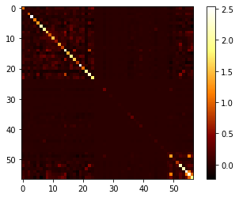

```python
showCov(COVS_2[1])
```

### Fold (3)

```python
_,MEANS_3,COVS_3,_ = getParameters(3)
```

Vector de medias de la clase $\omega_{0}$

```python
MEANS_3[0]
```

```
array([-0.10742035,  0.02939849, -0.16310639, -0.04867021, -0.18528897,
       -0.18726552, -0.26230602, -0.17324228, -0.18904063, -0.11063237,
       -0.17362036, -0.00056506, -0.09893611, -0.04145959, -0.16044193,
       -0.2086289 , -0.21394947, -0.15819781, -0.22030016, -0.15297676,
       -0.30474019, -0.07473283, -0.26253169, -0.16123165,  0.20495505,
        0.18760018,  0.14869252,  0.13507757,  0.1110375 ,  0.13557295,
        0.10973484,  0.09297694,  0.09654334,  0.09063822,  0.11339855,
        0.10668715,  0.13857945,  0.02586812,  0.10287418,  0.05131464,
        0.08169691,  0.11518017,  0.1104351 ,  0.08303634,  0.12134688,
        0.12143436,  0.03511736,  0.06965277,  0.0490338 ,  0.0975123 ,
        0.05232161, -0.18445519, -0.25053932, -0.04968807, -0.08505473,
       -0.24379866, -0.1996921 ])
```

Matriz de covarianza de cla clase $\omega_0$

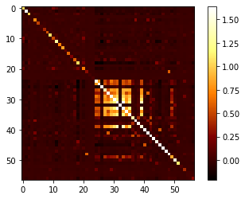

```python
showCov(COVS_3[0])
```

Vector de medias de la clase $\omega_{1}$

```python
MEANS_3[1]
```

```
array([ 0.16505692, -0.04517231,  0.25062141,  0.0747843 ,  0.28470609,
        0.28774315,  0.40304676,  0.26619573,  0.29047071,  0.16999235,
        0.26677666,  0.00086825,  0.15202045,  0.06370481,  0.24652732,
        0.3205691 ,  0.32874443,  0.24307911,  0.33850259,  0.2350567 ,
        0.46824907,  0.11483085,  0.40339353,  0.24774078, -0.31492404,
       -0.28825738, -0.22847375, -0.20755367, -0.17061486, -0.20831485,
       -0.16861325, -0.14286388, -0.14834384, -0.13927031, -0.17424274,
       -0.16393032, -0.2129345 , -0.03974771, -0.15807149, -0.0788476 ,
       -0.12553153, -0.17698029, -0.16968925, -0.12758963, -0.18645576,
       -0.18659018, -0.05395963, -0.10702508, -0.07534297, -0.14983269,
       -0.08039486,  0.28342495,  0.38496663,  0.07634828,  0.130691  ,
        0.37460925,  0.30683724])
```

Matriz de covarianza de cla clase $\omega_1$

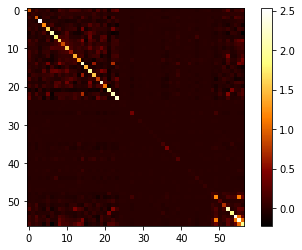

```python
showCov(COVS_3[1])
```

### Fold (4)

```python
_,MEANS_4,COVS_4,_ = getParameters(4)
```

Vector de medias de la clase $\omega_{0}$

```python
MEANS_4[0]
```

```
array([-0.09673673,  0.02383983, -0.16190483, -0.05095929, -0.20909467,
       -0.2103629 , -0.26692426, -0.16330756, -0.17957311, -0.09941211,
       -0.197604  , -0.01026023, -0.11080718, -0.06676604, -0.1584689 ,
       -0.20026559, -0.20824687, -0.16334664, -0.21112649, -0.17200792,
       -0.31599829, -0.08500086, -0.27398068, -0.20368354,  0.20700017,
        0.18663509,  0.15033422,  0.1243893 ,  0.10865727,  0.13894985,
        0.1017648 ,  0.09014453,  0.09605749,  0.08965944,  0.12043635,
        0.10679792,  0.13981806,  0.02785931,  0.10012422,  0.04923635,
        0.07668123,  0.10886477,  0.10717758,  0.07467603,  0.11055152,
        0.11511194,  0.03471775,  0.06782678,  0.04892626,  0.065404  ,
        0.06077025, -0.17998143, -0.25919736, -0.05281028, -0.0907158 ,
       -0.16221149, -0.19923479])
```

Matriz de covarianza de cla clase $\omega_0$

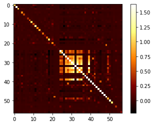

```python
showCov(COVS_4[0])
```

Vector de medias de la clase $\omega_{1}$

```python
MEANS_4[1]
```

```
array([ 0.14864099, -0.03663113,  0.24877514,  0.07830159,  0.32128478,
        0.32323348,  0.41014293,  0.25093052,  0.27592337,  0.15275185,
        0.30362877,  0.01576538,  0.17026096,  0.10258947,  0.24349567,
        0.30771845,  0.31998209,  0.25099057,  0.32440678,  0.26429907,
        0.48554772,  0.13060821,  0.42098549,  0.3129703 , -0.31806647,
       -0.28677447, -0.23099631, -0.1911306 , -0.16695751, -0.21350363,
       -0.15636688, -0.13851173, -0.14759731, -0.13776637, -0.18505668,
       -0.16410053, -0.21483768, -0.04280727, -0.15384604, -0.0756542 ,
       -0.11782468, -0.16727635, -0.1646839 , -0.11474358, -0.16986813,
       -0.17687545, -0.05334563, -0.10421935, -0.07517773, -0.10049662,
       -0.09337664,  0.27655077,  0.39827015,  0.08114573,  0.13938953,
        0.24924634,  0.30613456])
```

Matriz de covarianza de cla clase $\omega_1$

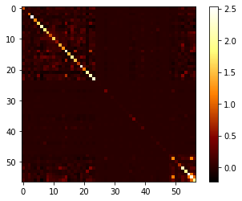

```python
showCov(COVS_4[1])
```

# Perceptron

```python
def cost_fn(X,w):
    return (-w.T@X).sum()
def GD(X,**kwargs):
#     w             = np.random.rand(X.shape[0]).reshape(-1,1)
    wp=w          = np.zeros(X.shape[0]).reshape(-1,1)
    lr            = kwargs.get('learning_rate',0.01)
    epochs        = kwargs.get('epochs',100)
    show_progress = kwargs.get('show_progress',False )
    jpws          = []
    i             = 0
    predicate     = True
    max_iteration_reached = False
    convergence_reached = False
    predicate = True
    h=hp=0
    while(predicate):
        gxs                   = w.T@X
        mask0                 = (gxs >0).T.flatten()
        mask1                 = (gxs <=0).T.flatten()
        _X_                   = X[:,mask1]
        delta_Jw              = -(_X_.sum(axis=1)).reshape(-1,1)
        Jw                    = cost_fn(_X_,w)
        w                     = w + (lr*delta_Jw)
#       Pocket
        h                    = mask0.astype(int).sum()
        #print(h,hp)
        if(h>hp):
            wp = w
            hp=h
#       End pocket
        max_iteration_reached = i>= epochs
        convergence_reached   = np.all(mask0)
        predicate             = not ( max_iteration_reached or convergence_reached )
        i+=1
    return w,convergence_reached,max_iteration_reached,wp,hp

def test_perceptron(**kwargs):
    epochs = kwargs.get("epochs",100)
    LR     = kwargs.get("learning_rate",0.0001)
    accurracies =[]
    acc2 =[]
    for INDEX in range(FOLDS):
        X_train,y_train = Xys_train[INDEX]
        _SS,(w0,w1)     = getWiByClass(X_train,y_train)
        XXX             = augmentX(np.concatenate([w0,-w1]).T)
        W,cr,mr,wp,hp   = GD(XXX,epochs=epochs,learning_rate=LR)
        X_test , y_test = Xys_test[INDEX]
        X               = augmentX(_SS.transform(X_test).T)
        n               = y_test.shape[0]
        res             = (((W.T@X)>0).astype(int) == y_test).astype(int).sum()/n
        res2            = (((wp.T@X)>0).astype(int) == y_test).astype(int).sum()/n
#         print("Fold[{}] Converge reached= {}\nMax. Iterations reached = {}\nhp={}\nn={}".format(INDEX,cr,mr,hp,n))
#         print("_"*100)
        accurracies.append(res)
        acc2.append(res2)
    return np.array(accurracies),np.array(acc2)
```

```python
perceptron_results,perceptron_results2  = test_perceptron(epochs=100,learning_rate=0.1)
perceptron_results.mean(),perceptron_results2.mean()
```

```
(0.8703486776742206, 0.8696957941051238)
```

## Resultados perceptron

```
[0 1 2 3 4]
```

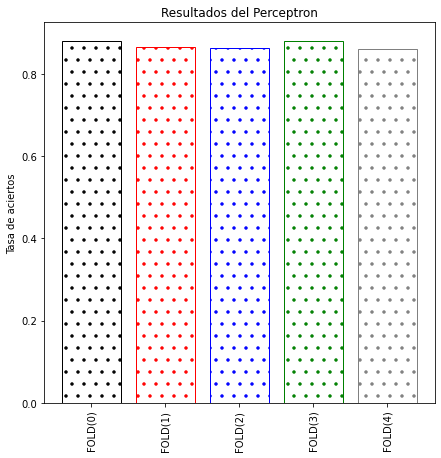

```python
plot_mean(
          perceptron_results,
          x_ticks= ["FOLD(0)","FOLD(1)","FOLD(2)","FOLD(3)","FOLD(4)"],
            title = "Resultados del Perceptron",
            y_label = "Tasa de aciertos",
            x_label = ""
         )
plt.savefig("p1",dpi=300)
```

### Resultados perceptron pocket

```
[0 1 2 3 4]
```

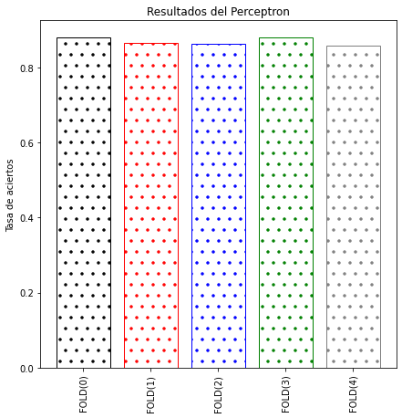

```python
plot_mean(
          perceptron_results2,
          x_ticks= ["FOLD(0)","FOLD(1)","FOLD(2)","FOLD(3)","FOLD(4)"],
            title = "Resultados del Perceptron",
            y_label = "Tasa de aciertos",
            x_label = ""
         )
# plt.savefig("p1",dpi=300
```

# Regresion logistica

#### Funcion sigmoid

```python
def sigmoid(x):
    return 1/(1+np.exp(-x))
```

### Funcion de costo

```python
def cross_entropy_loss(w,yi,_yi,**kwargs):
    l = kwargs.get("l",0.001)
#     return -(yi*np.log(_yi)+(1-yi)*np.log(1-_yi)+((l/2) *LA.norm(w)**2)).sum()
#     return -(yi*np.log(_yi)+(1-yi)*np.log(1-_yi)).sum()+((l/2) *LA.norm(w)**2)
    return -(yi*np.log(_yi)+(1-yi)*np.log(1-_yi)).sum()+((l/2) *LA.norm(w)**2)
```

### Descenso del gradiente

```python
def gradient_descent(X,y,**kwargs):
    LAMBDA       = kwargs.get("LAMBDA",1/(10**3))
    epochs       = kwargs.get("epochs",100)
    LR           = kwargs.get("learning_rate",0.001)
    threshold    = kwargs.get("threshold",1/(np.power(10,3)))
    show_entropy = kwargs.get("show_entropy",False)
    w            = np.zeros([D+1,1]).reshape(-1,1)
    predicate    =  True
    i            = 0

    while(predicate):
#       Linear discriminant function
        x                   = (w.T@X)
#       Mapping values to (0,1)
        _y                  = sigmoid(x)
#       Supervised learning
        yy                  = (_y-y)
#       Gradient
        delta_Lw            = X@(yy.T)
#       w(i) vector of weights at iteration k
        w_temp              = w
#       w(i+1) new vector of weights
        w                   = w-(LR*delta_Lw)  + LAMBDA*w
#       cross - entropy
        Lw                  = cross_entropy_loss(w,y,_y,l=LAMBDA)
        if(show_entropy):
            print("[{}]- CROSS ENTROPY LOSS: {}".format(i,Lw))
#       check exit conditions: Max iteration reached or Convergence
        norm_diff           = LA.norm(np.abs(w_temp-w))
        max_iter_reached    = epochs-1<=i
        convergence_reached = norm_diff < threshold
        predicate = not(( max_iter_reached or convergence_reached ))
#       Increment the counter
        i+=1
    return {'w':w,
            'max_iter_reached':max_iter_reached,
            'convergence_reached':convergence_reached,
            "iterations":i
           }
```

```python
def test_logistic():
    accuracies = []
    for INDEX in range(FOLDS):
        st = StandardScaler()
        X_train,y_train = Xys_train[INDEX]
        st.fit(X_train)
        XXX             = augmentX( st.transform(X_train).T)
#         XXX             = augmentX( X_train.T)
        result          = gradient_descent(XXX,y_train,show_entropy=False,LAMBDA=0)
        w = result['w']
#         print("Fold[{}]\nMax. iter reached = {}\nConvergence reached={}".format(INDEX,mr,cr))
        X_test , y_test = Xys_test[INDEX]
        X               = augmentX(st.transform(X_test).T)
#         X               = augmentX(X_test.T)
        n               = y_test.shape[0]
        res             = (((w.T@X)>0).astype(int) == y_test).astype(int).sum()/n
        accuracies.append(res)
    return np.array(accuracies)
```

```python
logistic_results = test_logistic()
logistic_results.mean()
```

```
0.9227730993045371
```

```python
from sklearn.linear_model import LogisticRegression
X_train, y_train = Xys_train[0]
X_test, y_test = Xys_test[0]
clf = LogisticRegression(random_state=0).fit(X_train, y_train)
(clf.predict(X_test) == y_test).astype(int).sum()/y_test.shape[0]
```

```
0.9206521739130434
```

### Resultados de regresion logistica

```
[0 1 2 3 4]
```

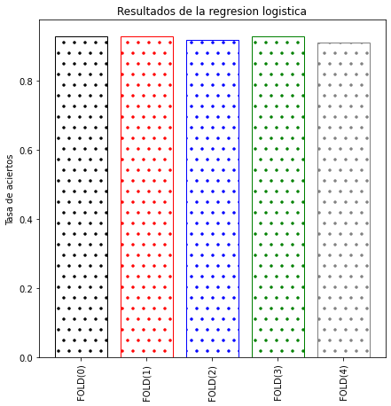

```python
plot_mean(logistic_results,
          x_ticks=["FOLD(0)","FOLD(1)","FOLD(2)","FOLD(3)","FOLD(4)"],
          title="Resultados de la regresion logistica",
          x_label="",
          y_label="Tasa de aciertos"
         )
plt.savefig("p2",dpi=300)
```

```
[0 1 2]
```

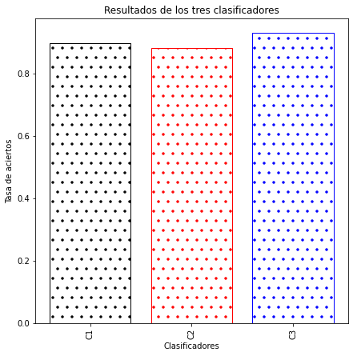

```python
data = np.array([bayes_tresults[1],perceptron_results.max(),logistic_results.max()])
plot_mean(data,
          x_ticks=["C1","C2","C3"],
          title="Resultados de los tres clasificadores",
          x_label="Clasificadores",
          y_label="Tasa de aciertos"
         )
```

## Utils

```python
def get_accuracy(y,y_pred):
    return (y==y_pred).astype(int).sum()/y.shape[0]
def augmentX(X):
    ones  = np.ones(X.shape[1])
    X_aug = np.vstack([ones,X])
    return X_aug

def getWiByClass(X,y):
    w0_mask = y==0
    w1_mask = y==1
    SS.fit(X)
    w0      = SS.transform(X[w0_mask])
    w1      = SS.transform(X[w1_mask])
    return SS,[w0,w1]
```